# Chapter 3 - Cluster

张笑竹 / 201618070114

2018年10月28日

第三章实验采用课本例3.5和例3.7中给出的数据进行聚类。例3.5是我国31个省、市及自治区的城镇居民消费水平，而例3.7是我国35家上市公司的2008年年报数据。  
将本次的实验任务拆分如下：  
1）编写系统聚类法的封装函数；  
2）利用1）中编写的函数对例3.5数据分别进行R型聚类和Q型聚类；  
3）利用K-means聚类法对例3.5数据进行Q型聚类；  
4）编写模糊聚类函数，并利用其对例3.7数据进行Q型聚类。

1 系统聚类法  
1.1 函数的封装  
首先，将数据复制进入剪贴板，在R中读入本次实验的数据集，并对数据集结构进行微调，将各个省份名称标记为行名，从而为后续分析得到更好的结果做铺垫。

```r
X=read.table("clipboard",header=T)
rownames(X)=X[,1]
X=X[,-1]
```

然后，对数据集进行标准化，分别利用dist()函数和hclust()函数对数据集进行系统聚类。需要注意的是，采用“系统聚类法”必须自行确定最终聚类数目，此处利用NbClust包中的NbClust()函数**确定最优聚类数目**。其原理是，利用26个指数（对应26种判定准则）进行计算；而这26个指数的结果可能不一致，因此通过“投票”的方式，选择出赞同判定准则数量最多的聚类数目。当多个聚类数目“票数”相同时，根据方便的原则，选择最小数目。

```r
H.clust <- function(X,d,m,gmin,gmax,ind){ #输入向量c(数据集X,"距离种类","聚类方法",允许最小类数,允许最大类数,"分类指标")
  X.scaled <- scale(X)
  dis <- dist(X.scaled,method=d)
  hc <- hclust(dis,method=m)
  #寻找最佳聚类数
  library(NbClust)
  devAskNewPage(ask=FALSE)
  nc <- NbClust(X.scaled,distance=d,min.nc=gmin,max.nc=gmax,method=m,index=ind)
  t <- table(nc$Best.n[1,])
  tframe <- as.data.frame(t)
  tframe1 <- tframe[which(tframe$Freq==max(t)),]
  k0=as.numeric(as.character(tframe1$Var1))[1]
  #结果输出
  clusters <- cutree(hc,k=k0)
  par(mfrow=c(1,1))
  barplot(t,xlab="Number of Clusters",ylab="Number of Criteria",main="Clusters Chosen")
  plot(hc,hang=-1)
  rect.hclust(hc,k=k0)
  return(list(clusters=table(clusters),median=aggregate(X,by=list(clusters=clusters),median)))
}
```

H.clust()函数的输入参数包括数据集X,“距离种类”,“聚类方法”,允许最小类数,允许最大类数,“分类指标”。最终将输出“聚类数目投票图”，聚类树状图，聚类频数表，以及各个类别的中位数。

1.2 R型聚类（变量聚类）  
首先，将数据集进行转置。  
然后，调用H.clust()函数，选择欧几里得距离、类平均法，允许最小类别数目为2、最大数目为7，选用silhouette和gap指数（准则），对变量进行聚类。

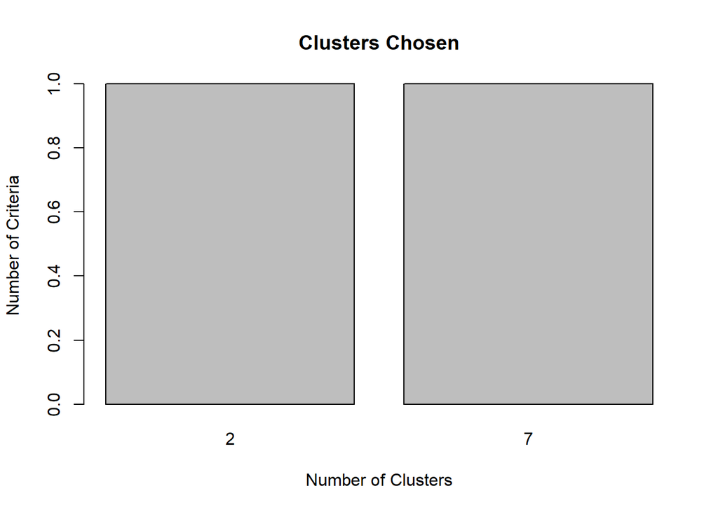

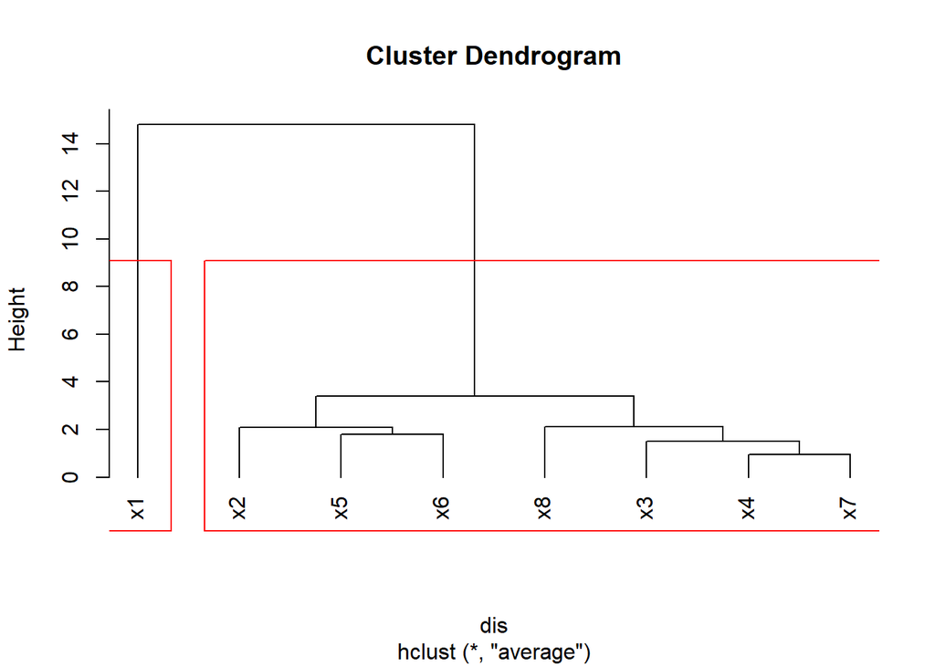

```
## $clusters
## clusters
## 1 2
## 1 7
##
## $median
##   clusters    北京    天津    河北    山西  内蒙古    辽宁    吉林  黑龙江
## 1        1 7535.29 7343.64 4211.16 3855.56 5463.18 5809.39 4635.27 4687.23
## 2        2 1970.94 1854.22 1203.80 1438.88 1583.56 1433.28 1594.14 1216.56
##      上海    江苏    浙江    安徽    福建    江西    山东    河南    湖北
## 1 9655.60 6658.37 7552.02 5814.92 7317.42 5071.61 5201.32 4607.47 5837.93
## 2 1906.49 1437.08 1551.69 1396.97 1634.21 1173.91 1572.35 1190.81 1371.15
##      湖南    广东    广西    海南    重庆    四川    贵州    云南    西藏
## 1 5441.63 8258.44 5552.56 6556.10 6870.23 6073.86 4992.85 5468.17 5517.69
## 2 1301.60 1520.59 1146.46  993.24 1196.03 1284.09 1013.53  973.76  580.05
##      陕西    甘肃    青海    宁夏    新疆
## 1 5550.71 4602.33 4667.34 4768.91 5238.89
## 2 1322.22 1287.93 1097.21 1193.37 1166.59
```

```r
X1=t(X)
H.clust(X1,"euclidean","average",2,7,c("silhouette","gap"))
```

根据输出结果，可以看出，“silhouette”和“gap”准则各“投”了2类和7类一票。根据方便的原则，最终确定了聚类数目为2类。当然，由输出的树状图可以看出，下面的分类方法也是可以的：变量$X_1$为一类，变量$X_2$、$X_5$、$X_6$为一类，变量$X_8$、$X_3$、$X_4$、$X_7$为一类。

1.3 Q型聚类（样品聚类）  
本节分别采用最短距离法、最长距离法、重心法、类平均法和Ward法对样品进行聚类。  
**1.3.1 最短距离法**  
调用H.clust()函数，选择最短距离法，对样品进行聚类。其中距离采用欧几里得距离，聚类数目准则选择全部(“all”)。

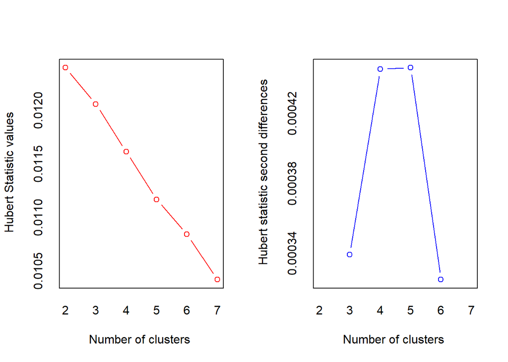

```
## *** : The Hubert index is a graphical method of determining the number of clusters.
##                 In the plot of Hubert index, we seek a significant knee that corresponds to a
##                 significant increase of the value of the measure i.e the significant peak in Hubert
##                 index second differences plot.
##
```

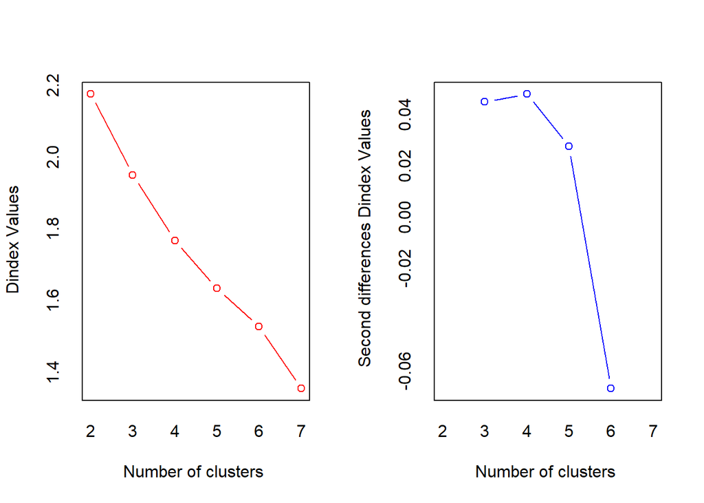

```
## *** : The D index is a graphical method of determining the number of clusters.
##                 In the plot of D index, we seek a significant knee (the significant peak in Dindex
##                 second differences plot) that corresponds to a significant increase of the value of
##                 the measure.
##
## * Among all indices:
## * 7 proposed 2 as the best number of clusters
## * 6 proposed 3 as the best number of clusters
## * 5 proposed 4 as the best number of clusters
## * 1 proposed 5 as the best number of clusters
## * 3 proposed 6 as the best number of clusters
## * 2 proposed 7 as the best number of clusters
##
##                    ***** Conclusion *****
##
## * According to the majority rule, the best number of clusters is  2
##
##
```

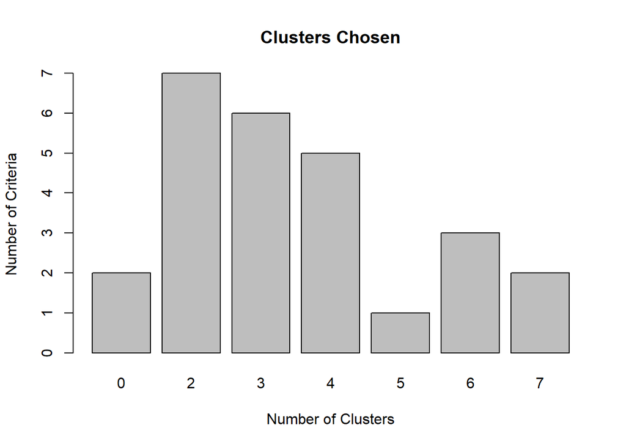

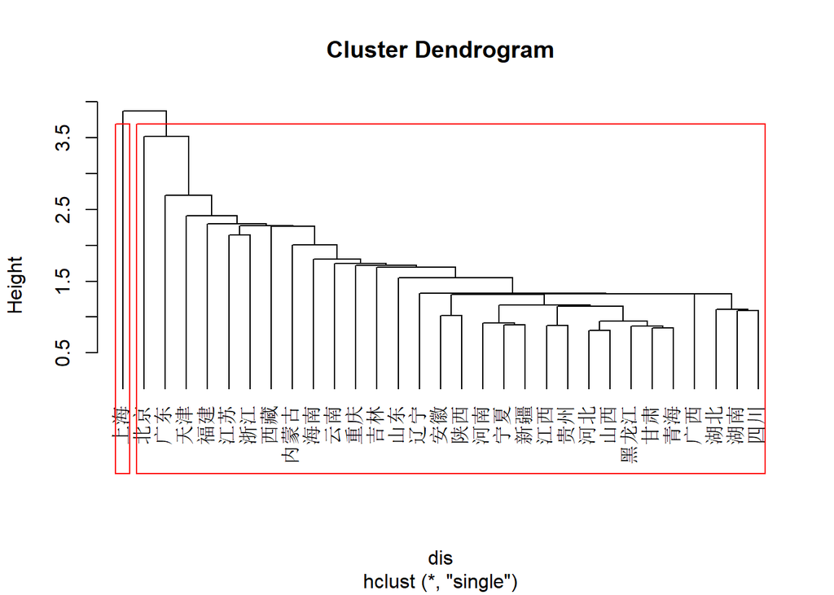

```
## $clusters
## clusters
##  1  2
## 30  1
##
## $median
##   clusters      x1      x2       x3      x4      x5      x6      x7
## 1        1 5492.93 1771.65 1374.205  982.54 1924.98 1606.74 1047.78
## 2        2 9655.60 2111.17 1790.480 1906.49 4563.80 3723.74 1016.65
##         x8
## 1  571.245
## 2 1485.530
```

```r
H.clust(X,"euclidean","single",2,7,"all")
```

根据结果不难看出，在最短距离法下，最优聚类数目为2类，上海单独为一类，其他所有省份为另外一类。聚类图呈现明显的链式形状。

**1.3.2 最长距离法**  
同理，调用H.clust()函数，选择最长距离法，对样品进行聚类。

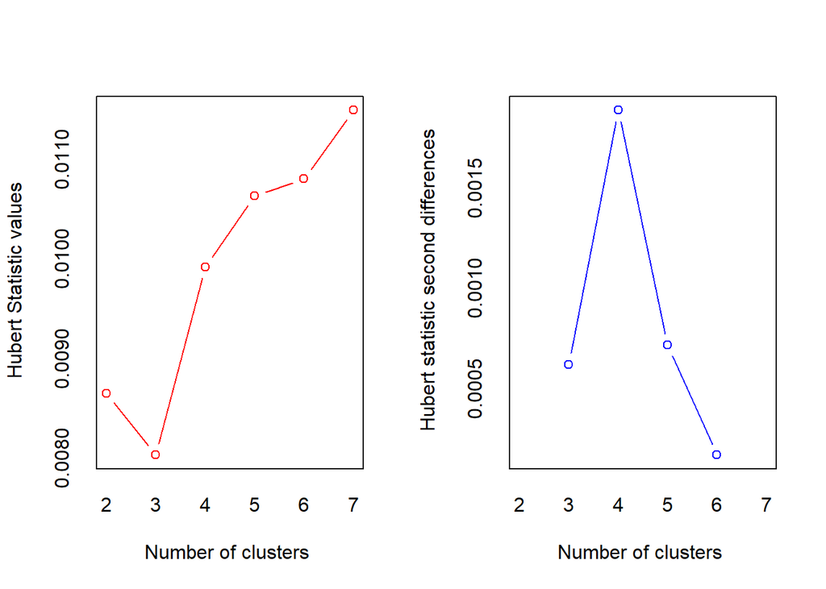

```
## *** : The Hubert index is a graphical method of determining the number of clusters.
##                 In the plot of Hubert index, we seek a significant knee that corresponds to a
##                 significant increase of the value of the measure i.e the significant peak in Hubert
##                 index second differences plot.
##
```

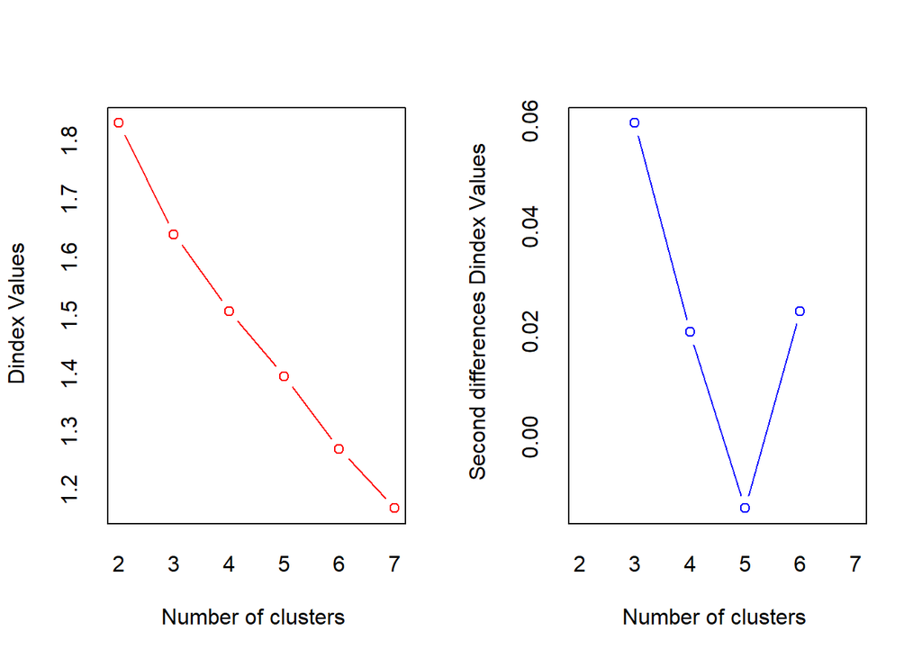

```
## *** : The D index is a graphical method of determining the number of clusters.
##                 In the plot of D index, we seek a significant knee (the significant peak in Dindex
##                 second differences plot) that corresponds to a significant increase of the value of
##                 the measure.
##
## * Among all indices:
## * 11 proposed 2 as the best number of clusters
## * 2 proposed 3 as the best number of clusters
## * 6 proposed 4 as the best number of clusters
## * 4 proposed 6 as the best number of clusters
## * 1 proposed 7 as the best number of clusters
##
##                    ***** Conclusion *****
##
## * According to the majority rule, the best number of clusters is  2
##
##
```

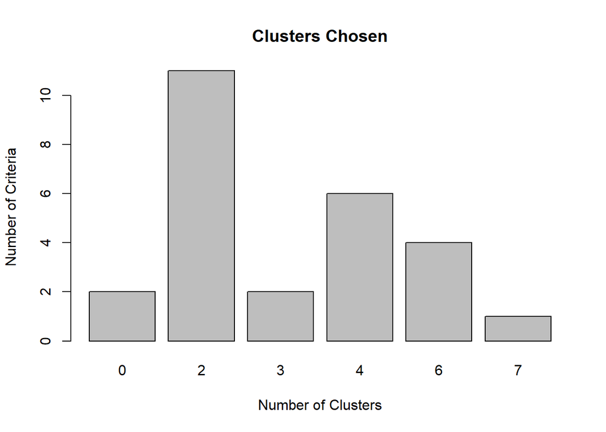

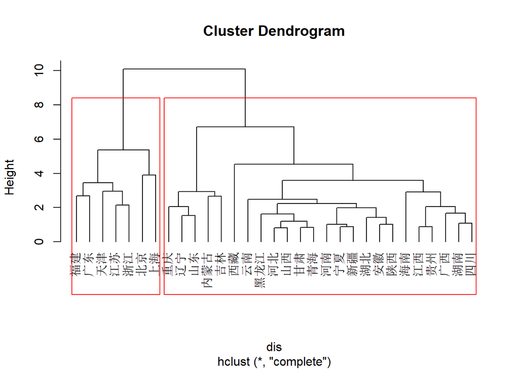

```
## $clusters
## clusters
##  1  2
##  7 24
##
## $median
##   clusters      x1       x2      x3      x4      x5       x6       x7
## 1        1 7535.29 1915.970 1790.48 1288.42 3781.51 2996.590 1058.110
## 2        2 5340.26 1705.515 1311.91  939.59 1799.05 1511.055 1028.575
##        x8
## 1 871.300
## 2 543.375
```

```r
H.clust(X,"euclidean","complete",2,7,"all")
```

这里，样品同样被分为2类，其中北京、上海、天津、江苏、浙江、广东和福建被聚为一类，其他省份被聚为另外一类。聚类图分类特征较为明显，结果较好。

**1.3.3 重心法**  
调用H.clust()函数，选择重心法，对样品进行聚类。

```r
H.clust(X,"euclidean","centroid",2,7,"all")
```

```
## [1] "Frey index : No clustering structure in this data set"
```

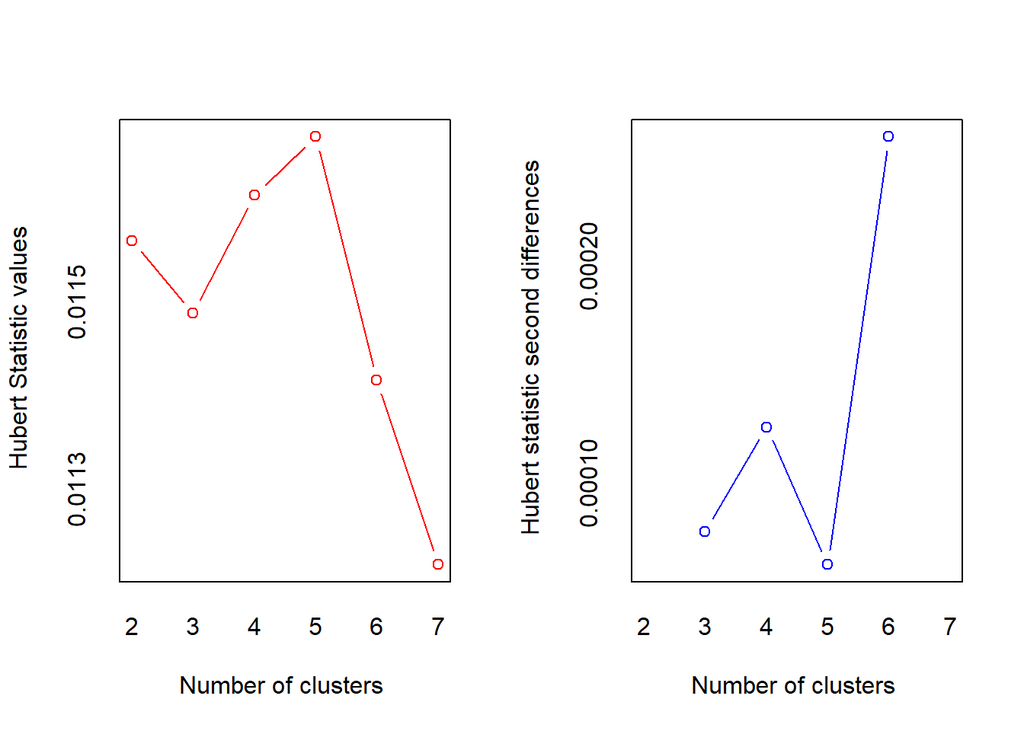

```
## *** : The Hubert index is a graphical method of determining the number of clusters.
##                 In the plot of Hubert index, we seek a significant knee that corresponds to a
##                 significant increase of the value of the measure i.e the significant peak in Hubert
##                 index second differences plot.
##
```

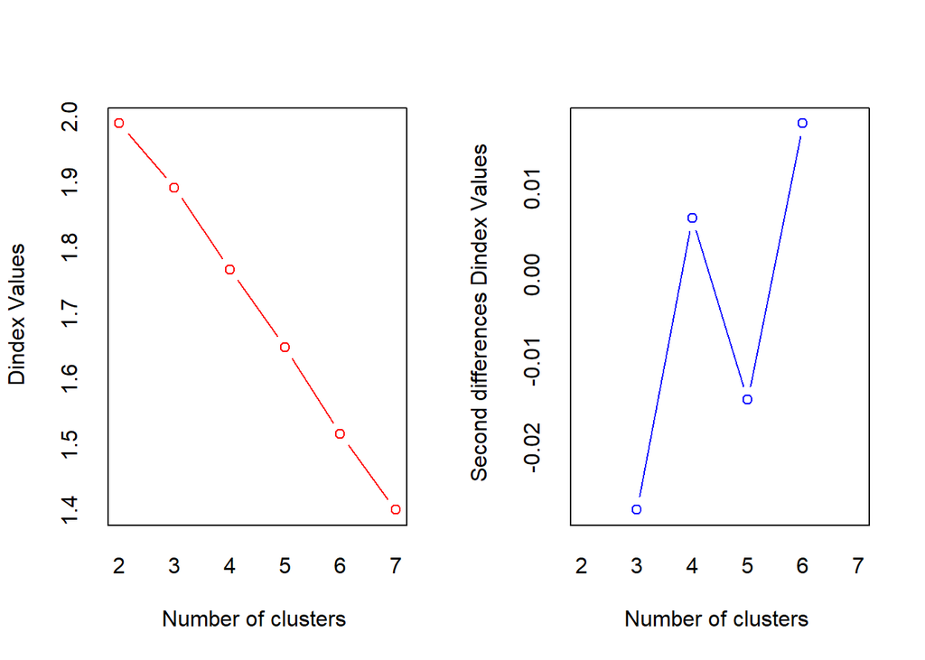

```
## *** : The D index is a graphical method of determining the number of clusters.
##                 In the plot of D index, we seek a significant knee (the significant peak in Dindex
##                 second differences plot) that corresponds to a significant increase of the value of
##                 the measure.
##
## * Among all indices:
## * 10 proposed 2 as the best number of clusters
## * 3 proposed 3 as the best number of clusters
## * 2 proposed 4 as the best number of clusters
## * 4 proposed 5 as the best number of clusters
## * 2 proposed 6 as the best number of clusters
## * 2 proposed 7 as the best number of clusters
##
##                    ***** Conclusion *****
##
## * According to the majority rule, the best number of clusters is  2
##
##
```

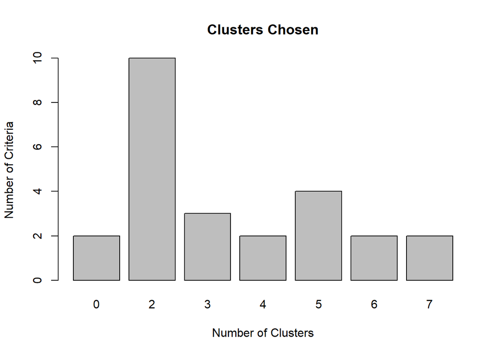

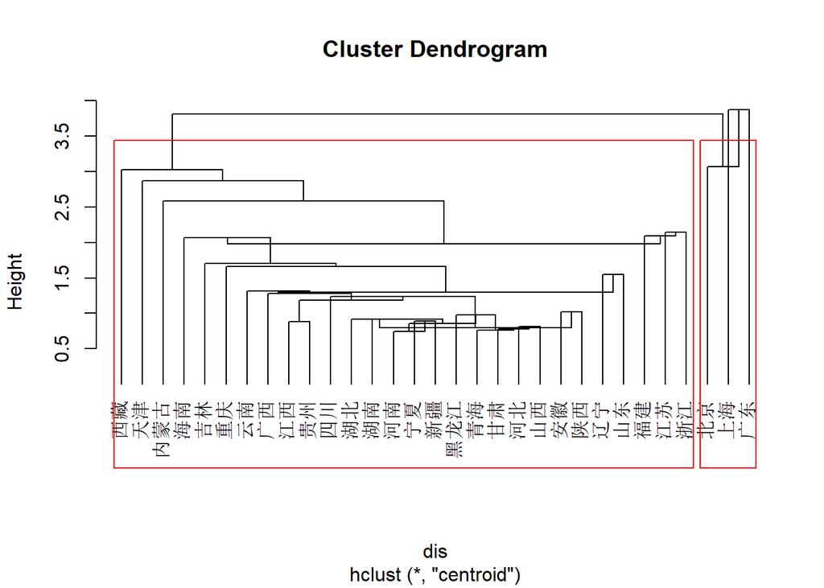

```
## $clusters
## clusters
##  1  2
##  3 28
##
## $median
##   clusters       x1      x2      x3       x4       x5      x6       x7
## 1        1 8258.440 2111.17 1970.94 1610.700 4176.660 3695.98 1048.280
## 2        2 5465.675 1771.65 1354.00  972.245 1897.135 1556.38 1038.415
##         x8
## 1 1154.180
## 2  562.285
```

从输出的结果不难看出，在重心法下，最优聚类数目为2类，北京、上海、广东为一类，其他所有省份为另外一类；聚类结果不是非常明显。

**1.3.4 类平均法**  
下面，调用H.clust()函数，利用类平均法进行聚类。

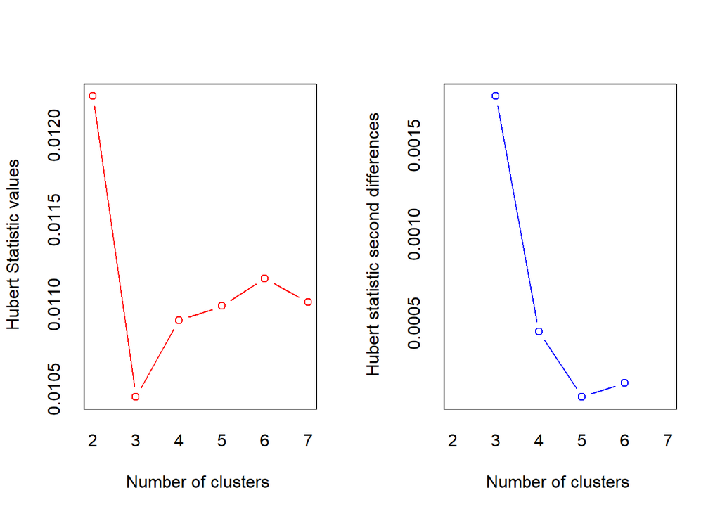

```
## *** : The Hubert index is a graphical method of determining the number of clusters.
##                 In the plot of Hubert index, we seek a significant knee that corresponds to a
##                 significant increase of the value of the measure i.e the significant peak in Hubert
##                 index second differences plot.
##
```

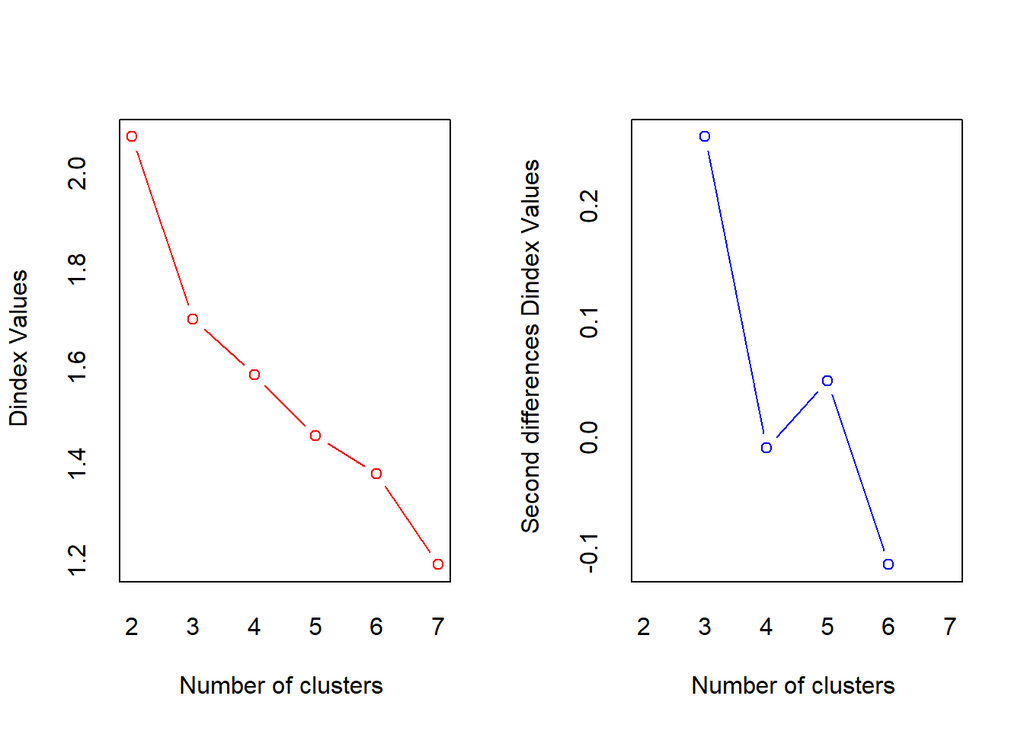

```
## *** : The D index is a graphical method of determining the number of clusters.
##                 In the plot of D index, we seek a significant knee (the significant peak in Dindex
##                 second differences plot) that corresponds to a significant increase of the value of
##                 the measure.
##
## * Among all indices:
## * 3 proposed 2 as the best number of clusters
## * 16 proposed 3 as the best number of clusters
## * 3 proposed 5 as the best number of clusters
## * 2 proposed 7 as the best number of clusters
##
##                    ***** Conclusion *****
##
## * According to the majority rule, the best number of clusters is  3
##
##
```

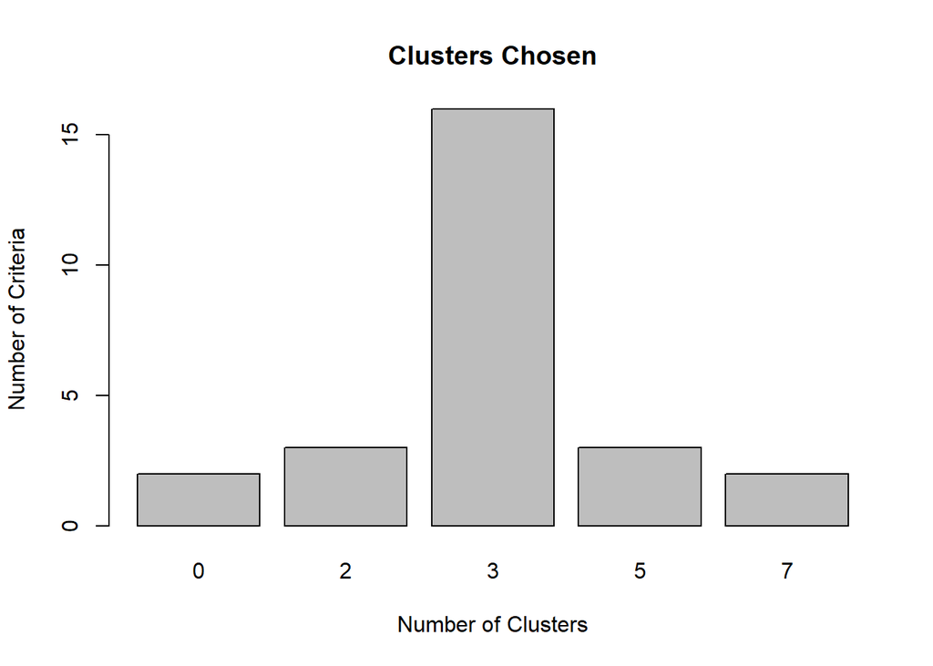

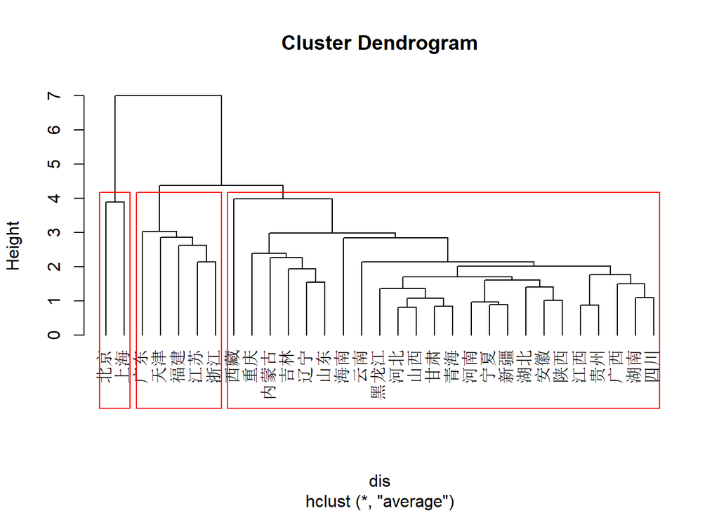

```
## $clusters
## clusters
##  1  2  3
##  2  5 24
##
## $median
##   clusters       x1       x2      x3       x4       x5       x6       x7
## 1        1 8595.445 2375.035 1880.71 1758.595 4172.655 3709.860 1337.510
## 2        2 7343.640 1881.430 1753.86 1254.710 3083.370 2954.130 1058.110
## 3        3 5340.260 1705.515 1311.91  939.590 1799.050 1511.055 1028.575
##         x8
## 1 1319.855
## 2  812.390
## 3  543.375
```

```r
H.clust(X,"euclidean","average",2,7,"all")
```

可见，在类平均法下，最优聚类数目为3类，北京、上海为一类，广东、天津、福建、江苏、浙江为一类，其他所有省份为另外一类；聚类效果十分明显。

**1.3.5 Ward法**  
最后，调用H.clust()函数，采用Ward法进行聚类。

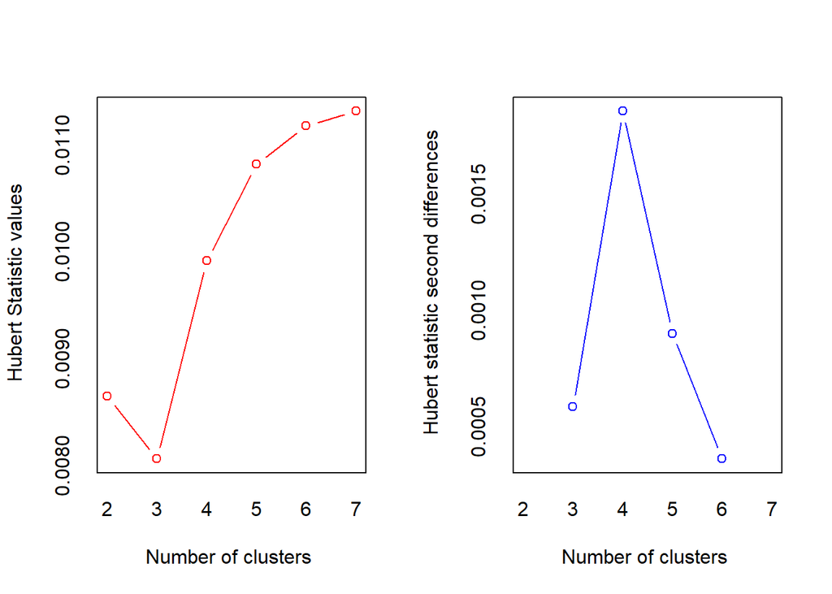

```
## *** : The Hubert index is a graphical method of determining the number of clusters.
##                 In the plot of Hubert index, we seek a significant knee that corresponds to a
##                 significant increase of the value of the measure i.e the significant peak in Hubert
##                 index second differences plot.
##
```

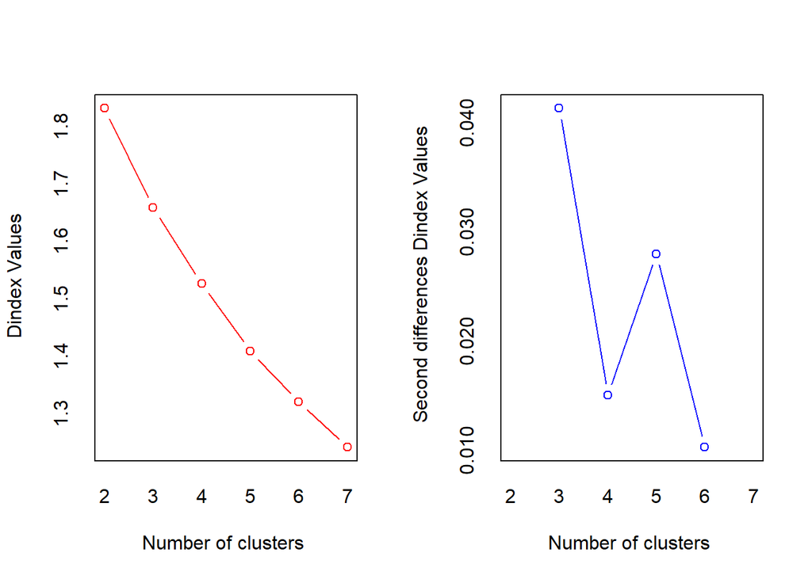

```
## *** : The D index is a graphical method of determining the number of clusters.
##                 In the plot of D index, we seek a significant knee (the significant peak in Dindex
##                 second differences plot) that corresponds to a significant increase of the value of
##                 the measure.
##
## * Among all indices:
## * 13 proposed 2 as the best number of clusters
## * 3 proposed 3 as the best number of clusters
## * 3 proposed 4 as the best number of clusters
## * 3 proposed 5 as the best number of clusters
## * 2 proposed 7 as the best number of clusters
##
##                    ***** Conclusion *****
##
## * According to the majority rule, the best number of clusters is  2
##
##
```

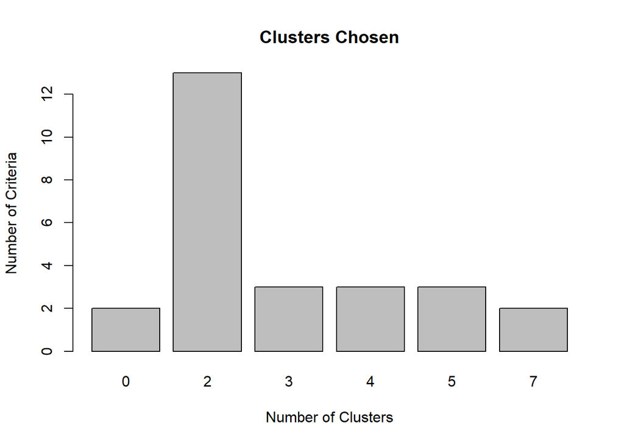

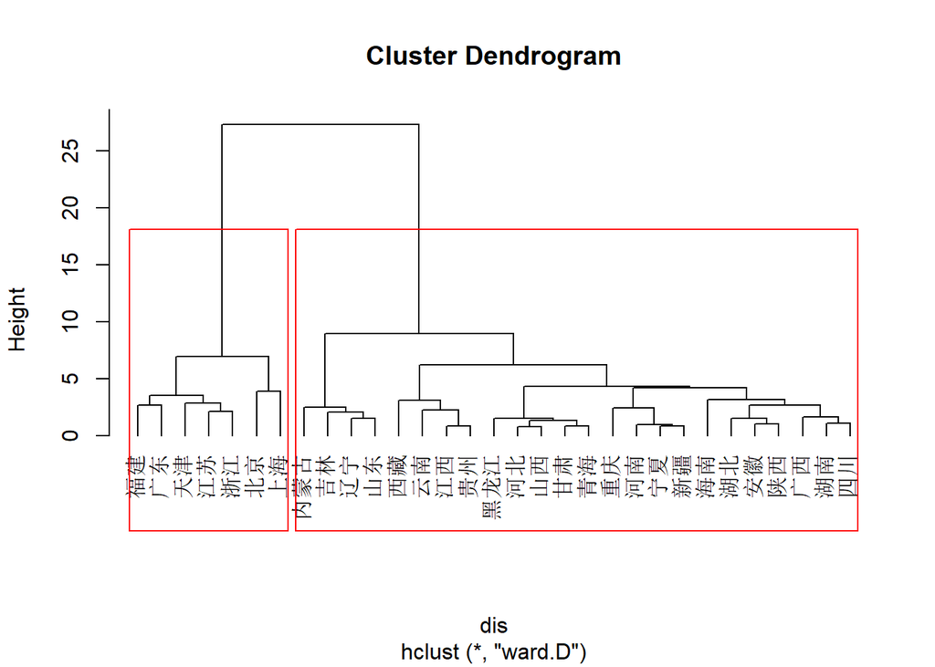

```
## $clusters
## clusters
##  1  2
##  7 24
##
## $median
##   clusters      x1       x2      x3      x4      x5       x6       x7
## 1        1 7535.29 1915.970 1790.48 1288.42 3781.51 2996.590 1058.110
## 2        2 5340.26 1705.515 1311.91  939.59 1799.05 1511.055 1028.575
##        x8
## 1 871.300
## 2 543.375
```

```r
H.clust(X,"euclidean","ward.D",2,7,"all")
```

在Ward法下，最优聚类数目为2类，北京、上海、广东、天津、江苏、浙江、福建为一类，其他所有省份为另外一类；聚类效果较为明显。

**1.3.6 总结**  
将上述5种系统聚类法的结果整理如下：

| 聚类方法 | 最优聚类数 | 类别是否明显 | 各类别样品数量 |
| --- | --- | --- | --- |
| 最短距离法 | 2 | 否，呈现链式 | 1,30 |
| 最长距离法 | 2 | 是 | 7,24 |
| 重心法 | 2 | 否 | 3,28 |
| 类平均法 | 3 | 是 | 2,5,24 |
| Ward法 | 2 | 是 | 7,24 |

综上所述，最短距离法和重心法聚类效果较差，而最长距离法、类平均法和Ward法聚类效果较好。 但是，类与类之间的样品数量差异过大，这或许是由最优聚类数的选取原则造成的。

2 K-means聚类法  
2.1 确定聚类数目  
与系统聚类法不同的是，K-means聚类法需要预先确定聚类的数目。利用factoextra包中的函数，画出“聚合”系数随分类数变化曲线，从而判定最佳聚类数。

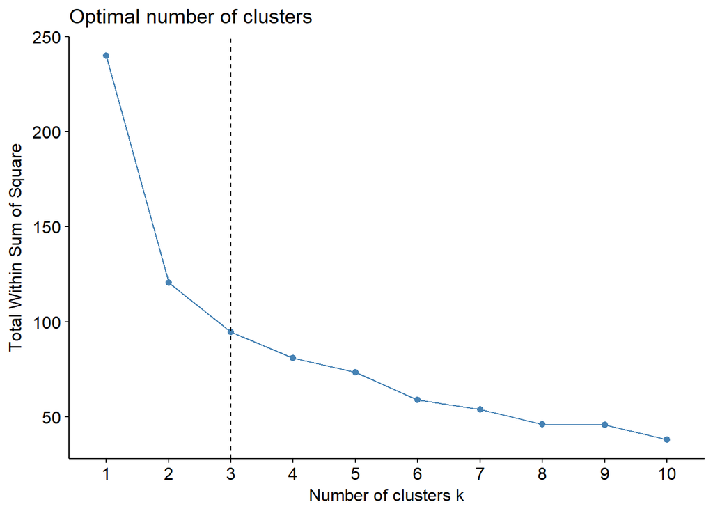

```r
#K-means聚类法
library(ggplot2)
library(factoextra)
df <- scale(X)
fviz_nbclust(df, kmeans, method = "wss") + geom_vline(xintercept = 3, linetype = 2)
```

不难看出，当分类数为3或4时，曲线变得比较平滑。因此，决定将所有省份分为3类。

2.2 进行聚类  
最后，利用kmeans()函数和fviz_cluster()函数，输出聚类中心、迭代次数、聚类频数和聚类图。

```r
set.seed(123)
km <- kmeans(df,3)
km$centers
```

```
##           x1         x2         x3         x4         x5        x6
## 1  1.8598918  0.8029115  1.5610874  1.7442512  2.2093299  2.037769
## 2 -0.5139319 -0.5239240 -0.5483537 -0.5455692 -0.5638815 -0.571046
## 3  0.2012452  0.6909984  0.4028909  0.3159158  0.1458385  0.236417
##           x7         x8
## 1  0.7456442  1.8804830
## 2 -0.4679504 -0.5932886
## 3  0.6045034  0.3508069
```

```r
km$iter
```

```
## [1] 2
```

```r
dd <- cbind(X, cluster = km$cluster)
table(dd$cluster)
```

```
##
##  1  2  3
##  4 18  9
```

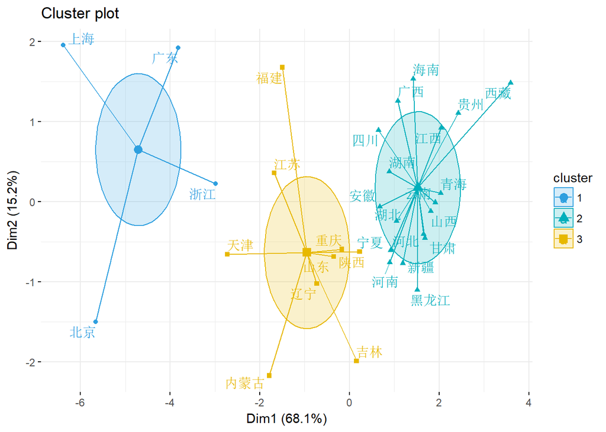

```r
fviz_cluster(km, data = df,
             palette = c("#2E9FDF", "#00AFBB", "#E7B800", "#FC4E07"),
             ellipse.type = "euclid",
             star.plot = TRUE,
             repel = TRUE,
             ggtheme = theme_minimal()
)
```

3 模糊聚类法  
本节中利用模糊聚类法，对例3.7进行聚类分析。  
相比起前面的“硬聚类”，FCM方法会计算每个样本对所有类的隶属度，这给了我们一个参考该样本分类结果可靠性的计算方法。若某样本对某类的隶属度在所有类的隶属度中具有绝对优势，则该样本分到这个类是一个十分保险的做法，反之若该样本在所有类的隶属度相对平均，则我们需要其他辅助手段来进行分类。  
首先，读入例3.7的数据集，并对数据集结构进行微调，将各个公司名称标记为行名。

```r
Y=read.csv("eg3-7.csv")
Y1=Y
rownames(Y1)=Y1[,1]
Y1=Y1[,-1]
Y1=Y1[,-1]
```

然后，利用fanny()函数，将样品分为3类。能够得到分类分布、样本隶属度以及聚类图。

```r
library(cluster)
fannyz=fanny(Y1,3,metric="SqEuclidean")
list("分类分布"=fannyz$clustering,"样本隶属度"=fannyz$membership)
```

```
## $分类分布
## 深圳能源 深南电Ａ 富龙热电 穗恒运Ａ 粤电力Ａ 韶能股份   ST惠天 城投控股
##        1        1        2        2        1        3        1        3
## 大连热电 华电能源 国电电力 长春经开 大龙地产 金丰投资   新黄浦 浦东金桥
##        1        3        1        1        2        2        1        3
##   外高桥 中华企业 渝开发Ａ 莱茵置业 粤宏远Ａ 中国国贸    万科A 三木集团
##        3        3        1        1        2        1        3        1
## 国兴地产   中关村 中兴通讯 长城电脑 南天信息 同方股份 永鼎股份 宏图高科
##        2        1        3        1        3        1        3        3
##   新大陆 方正科技 复旦复华
##        3        1        3
##
## $样本隶属度
##               [,1]       [,2]       [,3]
## 深圳能源 0.4627634 0.12736060 0.40987601
## 深南电Ａ 0.7345217 0.16278392 0.10269436
## 富龙热电 0.1051439 0.84951603 0.04534005
## 穗恒运Ａ 0.2759819 0.61552614 0.10849196
## 粤电力Ａ 0.5399324 0.07394796 0.38611962
## 韶能股份 0.4165089 0.06369778 0.51979333
## ST惠天   0.6117684 0.05954193 0.32868963
## 城投控股 0.3403638 0.14991098 0.50972524
## 大连热电 0.9122160 0.03022853 0.05755548
## 华电能源 0.4130828 0.09566793 0.49124932
## 国电电力 0.6881510 0.11404219 0.19780681
## 长春经开 0.5026950 0.15780149 0.33950355
## 大龙地产 0.1182967 0.82206364 0.05963965
## 金丰投资 0.1052065 0.84333634 0.05145713
## 新黄浦   0.4292140 0.41029852 0.16048745
## 浦东金桥 0.2472810 0.07509445 0.67762454
## 外高桥   0.2349805 0.05236040 0.71265906
## 中华企业 0.1273929 0.03223870 0.84036841
## 渝开发Ａ 0.4722216 0.35175332 0.17602508
## 莱茵置业 0.4560396 0.22828453 0.31567590
## 粤宏远Ａ 0.2398206 0.67411705 0.08606233
## 中国国贸 0.7950557 0.05062774 0.15431651
## 万科A    0.1700771 0.02752104 0.80240190
## 三木集团 0.5018610 0.25848080 0.23965818
## 国兴地产 0.2106219 0.65936591 0.13001216
## 中关村   0.5430426 0.18176835 0.27518905
## 中兴通讯 0.1392618 0.03291750 0.82782070
## 长城电脑 0.4506898 0.31274785 0.23656240
## 南天信息 0.3529242 0.25921507 0.38786075
## 同方股份 0.5827573 0.14226081 0.27498185
## 永鼎股份 0.1791461 0.03999553 0.78085840
## 宏图高科 0.1163364 0.02708346 0.85658013
## 新大陆   0.4257938 0.12898591 0.44522027
## 方正科技 0.6370565 0.23662056 0.12632292
## 复旦复华 0.4420571 0.04421677 0.51372617
```

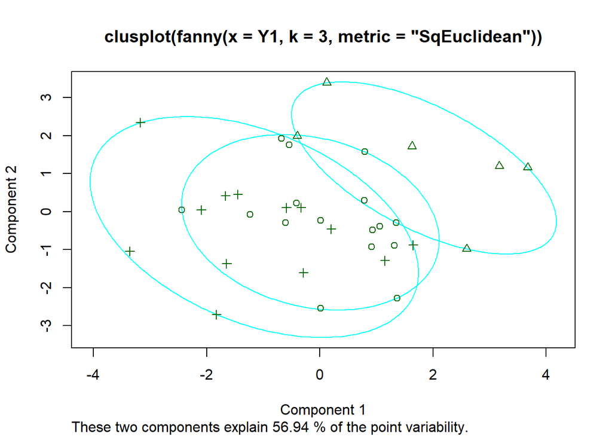

```r
clusplot(fannyz)
```

由于聚类图并不十分明显，因此，画出3D聚类图以提高视觉效果。

```r
library(e1071)
```

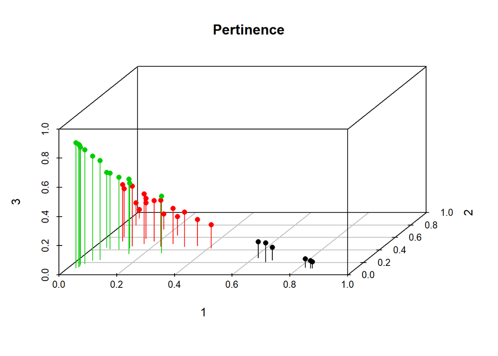

```r
result1<-cmeans(Y1,3,50)
library(scatterplot3d)
scatterplot3d(result1$membership, color=result1$cluster, type="h",
                     angle=55, scale.y=0.7, pch=16, main="Pertinence")
```

根据3D聚类图可以看出，类别之间的差距较为明显。事实上，该数据集中的公司来自于3大行业；为了验证聚类的合理性，将原行业与聚类后的类别进行对比，计算聚类的正确率。

```r
t=table(Y[,2],fannyz$clustering)
sum(diag(prop.table(t)))
```

```
## [1] 0.4571429
```

遗憾的是，最终的正确率仅有45.71%。鉴于这种情况，或许模糊聚类的效率与准确性仍待商榷。